# Word Predictor App!

DomR

Saturday, December 13, 2014

[output not shown]

```
## 'data.frame':    201 obs. of  7 variables:
##  $ r     : num  3 6 9 12 15 18 21 24 27 30 ...
##  $ n     : int  122077 12891 4652 2438 1478 970 692 481 384 351 ...
##  $ Z     : num  0 0 0 0 0 0 0 0 0 0 ...
##  $ logr  : num  0 0 0 0 0 0 0 0 0 0 ...
##  $ logZ  : num  0 0 0 0 0 0 0 0 0 0 ...
##  $ r_star: num  0 0 0 0 0 0 0 0 0 0 ...
##  $ p     : num  0 0 0 0 0 0 0 0 0 0 ...
## (Intercept) SGT_DT$logr
##       12.39       -2.25
```

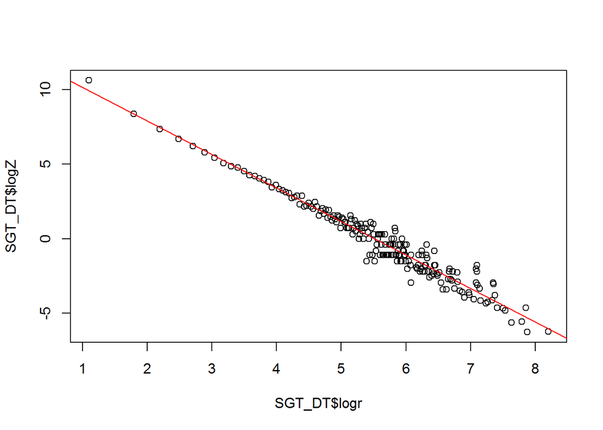

```
## 'data.frame':    78 obs. of  7 variables:
##  $ r     : num  3 6 9 12 15 18 21 24 27 30 ...
##  $ n     : int  207372 9439 2718 1248 677 446 260 197 161 107 ...
##  $ Z     : num  0 0 0 0 0 0 0 0 0 0 ...
##  $ logr  : num  0 0 0 0 0 0 0 0 0 0 ...
##  $ logZ  : num  0 0 0 0 0 0 0 0 0 0 ...
##  $ r_star: num  0 0 0 0 0 0 0 0 0 0 ...
##  $ p     : num  0 0 0 0 0 0 0 0 0 0 ...
## (Intercept) SGT_DT$logr
##      12.859      -2.696
```

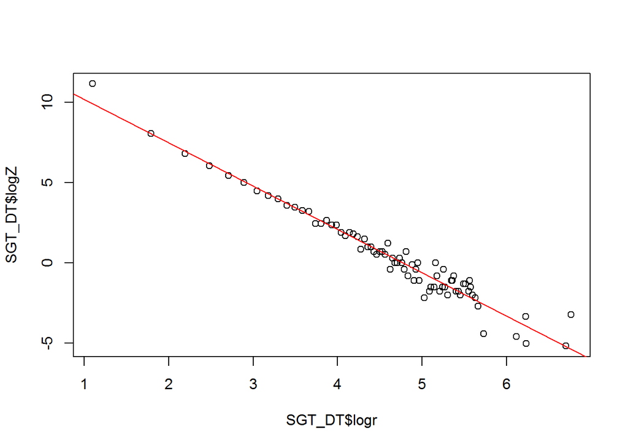

```
## 'data.frame':    34 obs. of  7 variables:
##  $ r     : num  3 6 9 12 15 18 21 24 27 30 ...
##  $ n     : int  222224 3642 775 263 137 75 56 33 25 19 ...
##  $ Z     : num  0 0 0 0 0 0 0 0 0 0 ...
##  $ logr  : num  0 0 0 0 0 0 0 0 0 0 ...
##  $ logZ  : num  0 0 0 0 0 0 0 0 0 0 ...
##  $ r_star: num  0 0 0 0 0 0 0 0 0 0 ...
##  $ p     : num  0 0 0 0 0 0 0 0 0 0 ...
## (Intercept) SGT_DT$logr
##      12.630      -3.133
```

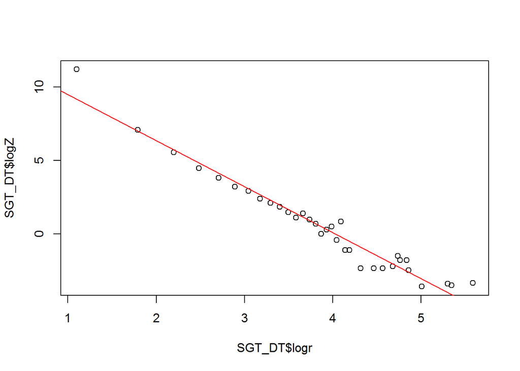

## What does *Word Predictor* App do?

- *Word Predictor* App will try to predict next word based on last three words the sentence. This app also provides five most likely words using corpus data from from [Capstone Dataset](https://d396qusza40orc.cloudfront.net/dsscapstone/dataset/Coursera-SwiftKey.zip). The files in the data set are en_US_twitter.txt,en_US_news.txt and en_US_blogs.txt.

## How does it work?

- From given corpus data, a sample (20% of original dataset) was selected for building the prediction engine. [see sampleData.r] (https://github.com/dxrodri/datasciencecoursera/tree/master/SwiftKeyCapstone). Using this sample data, a prediction algorithm was build using R tm package. A lookup datagrams for bigrams, trigrams and quadgrams was build using the TermDocumentMatrix function.

## How does it work (continued)?

Frequency distribution for each grams was calculated and smoothing techniques using Simple Good Turing algorithm was then applied for each grams. Given a sentence, the prediction algorithms selects five probable words given the weightage for matched grams as follows: 50% for quadrams,30% to trigrams and 20% for bigrams. [see predictFunctions_V1.r] (https://github.com/dxrodri/datasciencecoursera/tree/master/SwiftKeyCapstone).

## Demo Please!

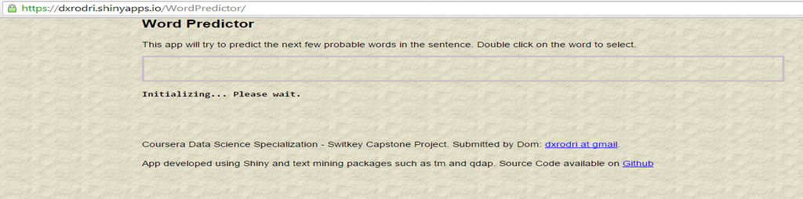

## How much does it cost?

- Free. Android and IOS based App coming soon.